# Last lab!

### Office Hours

1. Tomorrow, I'll go 9:00-10:30 AM. Come with questions.
   1. I have discussion from 2:10-3:00 in Wheeler 124 as well.
   2. Next week, 9:00-10:30 AM on Friday as well. No Monday.

### Infographic

This is due on the 7th on 5pm. Your proposals will be looked over. If you're not told otherwise, you're good.

### Review Sessions

1. Monday, Wednesday, Friday at 8-9 AM in Li Ka Shing.
2. Practice questions are released under Final Exam Review folder on bCourses. </font>

### Content

Heavily focused on Part III, but the subject matter is cumulative  
Review sessions are "valuable"

### "Crib sheet"

Same as before. 1 page, same guidelines. You'll have an equation sheet... but you'll have to recognize these things. I apologize?

### Code Necessities

There is more code than is necessary for the exam within this notebook... pay attention only to the following.

#### Distribution Functions

We `pnorm` and `qnorm` to calculate `p`robabilities and `q`uantiles for a normal distribution. You also need `pt`, `qt`, and `pchisq`.

tidy  
glance  
`augment` Don't augment the dataframe. Augment the linear model.

We use `lm` to make `l`inear `m`odels.  
You need `aov` for your F-test. (See ANOVA below.)  
You need `predict` from the world of linear regression. (See lab.) </font>

### Interpretation

`ggplot2`  
`dplyr`  
</font>

# New this week. Analysis of Variance.

ANOVA is nothing totally different than what you're using to. What this means for you is that we're doing the F-test. Like the other tests, the name in front of the test is the name of a distribution.

We will be looking at data that look like this. </font>

```r
groups <- cbind("group_1", "group_2", "group_3", "group_k")

values <- lapply(1:4, function(x) runif(15, 0, 100))
values <- data.frame(do.call(cbind, values))

names(values) <- groups
values
```

| group_1 | group_2 | group_3 | group_k |
| --- | --- | --- | --- |
| 1.078974 | 45.853776 | 67.3876087 | 89.060001 |
| 43.485962 | 25.347964 | 84.1581032 | 50.267509 |
| 96.448578 | 2.655742 | 42.5167292 | 67.746999 |
| 11.493893 | 54.023102 | 21.3142793 | 49.930421 |
| 90.283501 | 79.027486 | 65.2763417 | 20.322345 |
| 64.433351 | 28.327148 | 93.0615224 | 5.358334 |
| 71.221161 | 58.219872 | 46.5050540 | 83.879548 |
| 16.947358 | 63.598982 | 19.0725306 | 90.537611 |
| 41.576571 | 55.409839 | 30.0676575 | 14.745989 |
| 36.899950 | 48.258574 | 21.3380388 | 95.837700 |
| 42.777855 | 93.853638 | 91.5993112 | 99.669502 |
| 1.743857 | 84.365987 | 82.1951139 | 20.316152 |
| 5.472901 | 25.160614 | 11.8597290 | 8.757535 |
| 18.847923 | 21.078640 | 0.5562568 | 90.611898 |
| 56.198888 | 70.951467 | 22.8036103 | 77.329258 |

They have means.

```r
values %>% summarize_all(mean)
```

| group_1 | group_2 | group_3 | group_k |
| --- | --- | --- | --- |
| 39.92738 | 50.40886 | 46.64746 | 57.62472 |

```r
means <- values %>% summarize_all(mean)
var(unlist(means[1,]))
```

54.5778004508478

They have variances.

```r
values %>% summarize_all(var)
```

| group_1 | group_2 | group_3 | group_k |
| --- | --- | --- | --- |
| 967.3459 | 676.6959 | 990.0434 | 1244.48 |

### F Distribution

You don't need to know this, but the F distribution is ratio between two $\chi^2$ distributions. Thus, it's a positive distribution and (this you need to know) has two degrees of freedom.

### F Test (For equal means among k groups)

We can test the following hypotheses.  
$H_o: \, \mu_k$ is the same for all $k$  
$H_1: \, \mu_k \neq 0$ for at least one $k$

Yes, the alternative is awkward. Live with it. </font>

### F Statistic

If the means of all the groups are similar, then the between group variance is small. If the variance of a single group or multiple groups is large, then we expect a larger within group variance.

$F= \frac {\text{variability BETWEEN groups}} {\text {variability WITHIN groups}}$ </font>

### Assumptions

See bCourses Ch. 24 on the last few pages. These are extensively detailed. In short,

1. SRS
2. Normal would be nice
3. Same standard deviation between pops

```r
library(reshape2)
melt_values <- melt(values)

model <- lm(value ~ variable, data=melt_values)
model
```

```
Call:
lm(formula = value ~ variable, data = melt_values)

Coefficients:
    (Intercept)  variablegroup_2  variablegroup_3  variablegroup_k
          39.93            10.48             6.72            17.70
```

```r
# melt_values
```

```r
library(broom)
# aov(lm(y~x))
anova <- aov(model)
tidy(anova)
```

| term | df | sumsq | meansq | statistic | p.value |
| --- | --- | --- | --- | --- | --- |
| variable | 3 | 2456.001 | 818.6670 | 0.8442988 | 0.475443 |
| Residuals | 56 | 54299.913 | 969.6413 | NA | NA |

We can get the degrees of freedom with k-1 and N-k.

```r
pf(0.8444, df1=4-1, df2=nrow(melt_values)-4, lower.tail=F)
```

0.475390077217608

Material overload. Here's Tukey's HSD. We're going to do pairwise testing between each of the groups to see if the means are the same or not. Notice these are adjusted/corrected for "multiple testing".

```r
# TukeyHSD(aov(lm(y~x)))
many_tests <- TukeyHSD(anova, conf.level=0.05) %>% tidy()
many_tests
```

| term | comparison | estimate | conf.low | conf.high | adj.p.value |
| --- | --- | --- | --- | --- | --- |
| variable | group_2-group_1 | 10.481474 | 4.3919638 | 16.570984 | 0.7933050 |
| variable | group_3-group_1 | 6.720078 | 0.6305675 | 12.809588 | 0.9343905 |
| variable | group_k-group_1 | 17.697339 | 11.6078286 | 23.786849 | 0.4115235 |
| variable | group_3-group_2 | -3.761396 | -9.8509065 | 2.328114 | 0.9873787 |
| variable | group_k-group_2 | 7.215865 | 1.1263546 | 13.305375 | 0.9204055 |
| variable | group_k-group_3 | 10.977261 | 4.8877509 | 17.066771 | 0.7695074 |

### References.

http://blog.minitab.com/blog/adventures-in-statistics-2/understanding-analysis-of-variance-anova-and-the-f-test

# The lab. Regression test.

### Return to the Rappers Dataset

For those of you who watched my midterm 1 review vids, this dataframe should be familiar. For those of you who want to run this at home, run the very last chunk first.

```r
rapper_df
```

| artist_name | legal_name | age | origin | net_worth | start_year |
| --- | --- | --- | --- | --- | --- |
| Nicki Minaj | Onika Maraj | 35 | New York | 75.0 | 2004 |
| Jay Z | Shawn Carter | 48 | New York | 900.0 | 1986 |
| Eminem | Marshall Mathers | 45 | Missouri | 190.0 | 1988 |
| Kendrick Lamar | Kendrick Duckworth | 31 | California | 45.0 | 2003 |
| Logic | Robert Hall | 28 | Maryland | 10.0 | 2009 |
| E-40 | Earl Stevens | 50 | California | 10.0 | 1986 |
| Nas | Nasir Jones | 45 | New York | 50.0 | 1991 |
| Jadakiss | Jason Phillips | 43 | New York | 6.0 | 1991 |
| Chance the Rapper | Chancelor Bennett | 25 | Illinois | 33.0 | 2011 |
| Childish Gambino | Donald Glover | 34 | California | 12.0 | 2002 |
| Kanye West | Kanye West | 41 | Georgia | 160.0 | 1996 |
| Cardi B | Belcalis Almanzar | 25 | New York | 8.0 | 2015 |
| G-Eazy | Gerald Gillum | 29 | California | 9.0 | 2008 |
| 2Pac | Tupac Shakur | 49 | California | 40.0 | 1987 |
| YG | Keenon Jackson | 28 | California | 3.0 | 2009 |
| ScHoolboy Q | Quincy Hanley | 31 | California | 4.0 | 2008 |
| Lupe Fiasco | Wasalu Jaco | 36 | Chicago | 14.0 | 2000 |
| Drake | Aubrey Graham | 31 | International | 100.0 | 2001 |
| Joey BadA$$ | Jo-Vaughn Scott | 23 | New York | 4.0 | 2010 |
| Snoop Dogg | Calvin Broadus | 46 | California | 135.0 | 1991 |
| Iamsu! | Sudan Williams | 28 | California | 1.0 | 2007 |
| J. Cole | Jermaine Cole | 33 | New York | 15.0 | 2007 |
| Gucci Mane | Radric Davis | 38 | Georgia | 12.0 | 2001 |
| Rich Brian | Brian Imanuel | 19 | International | 0.3 | 2015 |
| Too $hort | Todd Shaw | 52 | California | 15.0 | 1984 |
| Mac Dre | Andre Hicks | 48 | California | 1.5 | 1984 |
| Missy Elliott | Melissa Elliott | 47 | Virginia | 50.0 | 1989 |
| Notorious B.I.G. | Christopher Wallace | 46 | New York | 160.0 | 1992 |

### Scatterplot

Before you make a linear model, you're gonna wanna check if the data look somewhat linear.

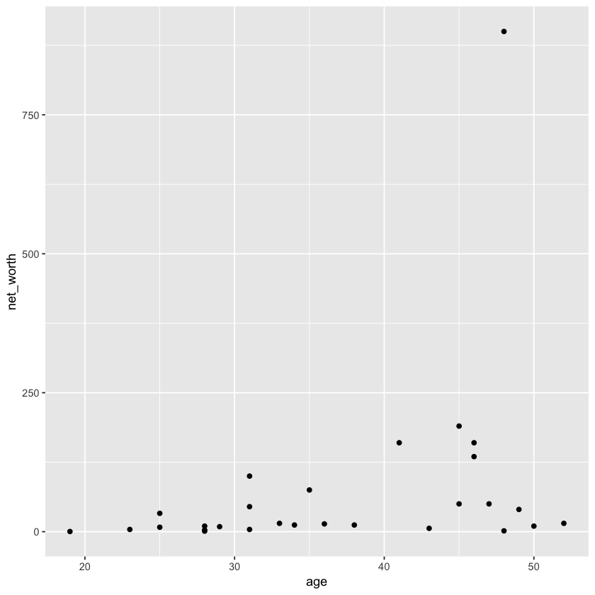

```r
library(ggplot2)
ggplot(rapper_df, aes(x=age, y=net_worth)) + geom_point()
```

Honestly, these data don't look so linear. We're going to run a model through it for education purposes though.

### Fit the model

We can fit a linear model of age and net worth using `lm`.

```r
library(dplyr)
net_worth <- rapper_df %>% pull(net_worth)
age <- rapper_df %>% pull(age)
model <- lm(net_worth ~ age)
```

Check out what `glance` does.

```r
library(broom)
glance(model)
```

|  | r.squared | adj.r.squared | sigma | statistic | p.value | df | logLik | AIC | BIC | deviance | df.residual |
| --- | --- | --- | --- | --- | --- | --- | --- | --- | --- | --- | --- |
| value | 0.1112938 | 0.07711283 | 164.3523 | 3.256014 | 0.08275907 | 2 | -181.5491 | 369.0982 | 373.0948 | 702303.5 | 26 |

```r
library(broom)
tidy(model)
```

| term | estimate | std.error | statistic | p.value |
| --- | --- | --- | --- | --- |
| (Intercept) | -146.427843 | 125.868666 | -1.163338 | 0.25525806 |
| age | 5.960135 | 3.303033 | 1.804443 | 0.08275907 |

### Why do we have p-values in our output?

Because of formal hypothesis testing. We'll get to this soon.

### Write the model

We have $y=mx+b$ with $m=5.9601$ and $b=-146.4278$.

### Interpret the parameters

According to our data, we see that as an artist gets older by a year, the artist's net worth increases by 5.96 million dollars.

### Calculate associated regression values

We'll use `augment` to get fitted values and residuals. Pay attention to how I renamed the columns so it's not super confusing.

```r
augmented_model <- augment(model)
augmented_model <- augmented_model %>%
                    select(net_worth, age, .fitted, .resid) %>%
                    rename(fitted=.fitted,
                           residual=.resid)
head(augmented_model)
```

| net_worth | age | fitted | residual |
| --- | --- | --- | --- |
| 75 | 35 | 62.17688 | 12.823118 |
| 900 | 48 | 139.65864 | 760.341362 |
| 190 | 45 | 121.77823 | 68.221767 |
| 45 | 31 | 38.33634 | 6.663658 |
| 10 | 28 | 20.45594 | -10.455937 |
| 10 | 50 | 151.57891 | -141.578908 |

### We can make so many plots with this dataframe

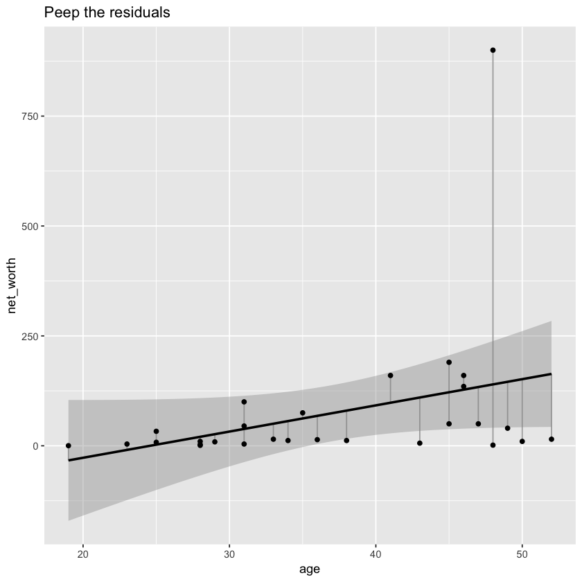

```r
ggplot(augmented_model, aes(y=net_worth, x=age)) +
    geom_segment(aes(xend=age, yend=fitted), color="darkgrey") +
    geom_smooth(method="lm", color="black") +
    geom_point() +
    ggtitle("Peep the residuals")
```

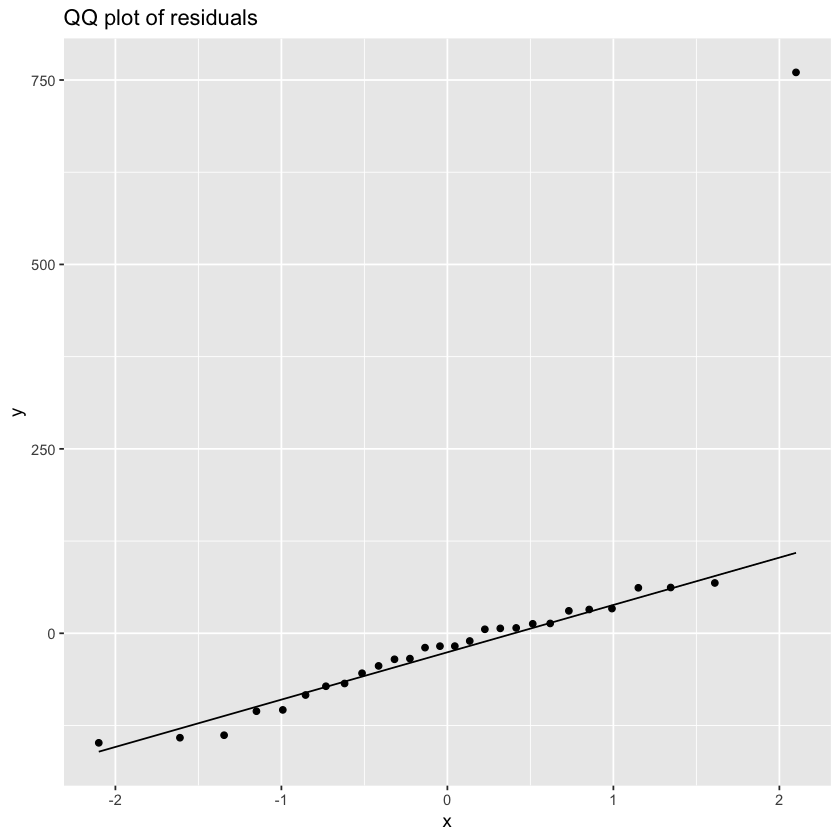

```r
ggplot(augmented_model, aes(sample=residual)) +
    geom_qq_line(col="black") +
    geom_qq() +
    ggtitle("QQ plot of residuals")
```

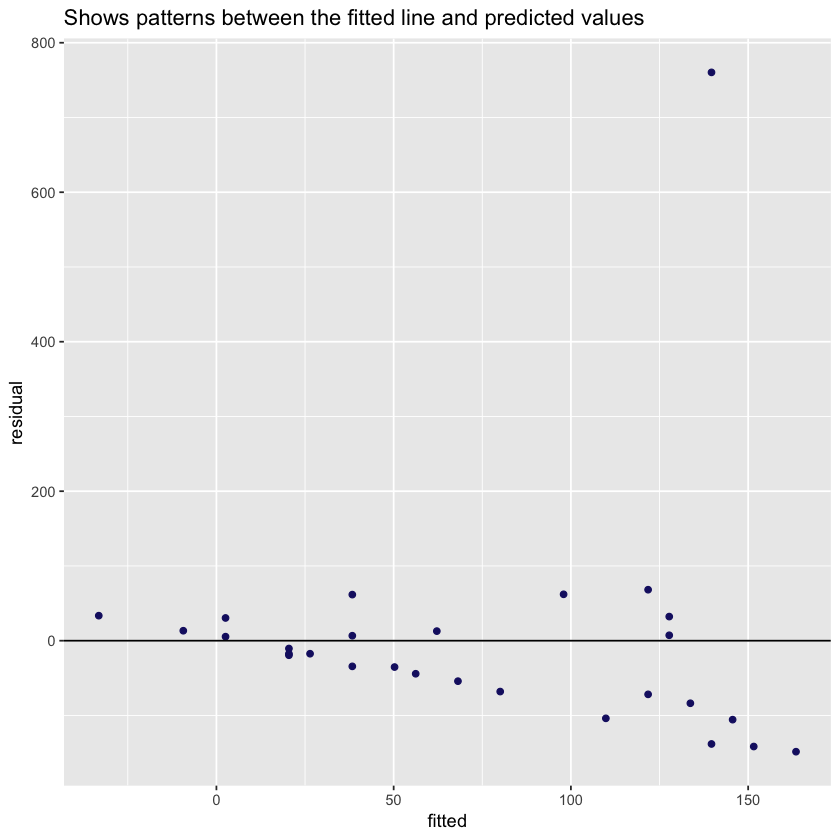

```r
ggplot(augmented_model, aes(y=residual, x=fitted)) +
    geom_point(col="midnightblue") +
    geom_hline(aes(yintercept = 0)) +
    ggtitle("Shows patterns between the fitted line and predicted values")
```

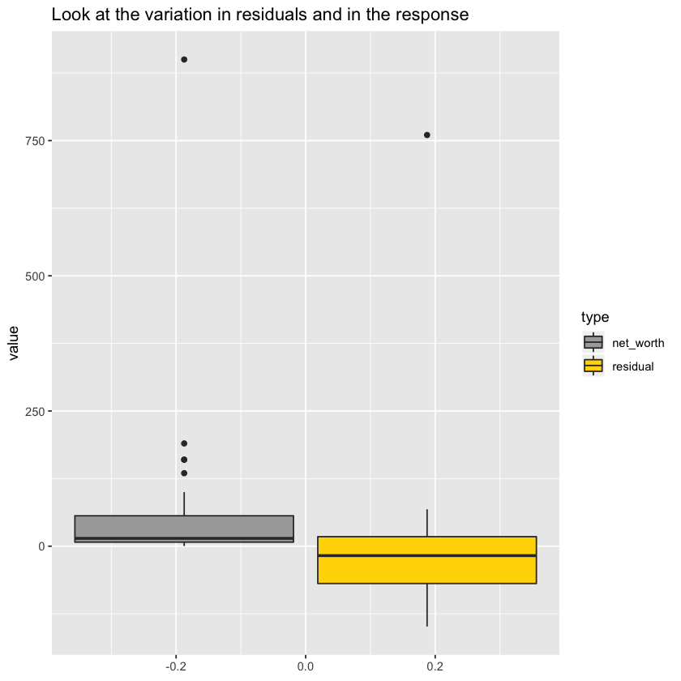

```r
library(tidyr)

reshape <- augmented_model %>% dplyr::select(residual, net_worth) %>%
              gather(key="type", value="value", net_worth, residual)

ggplot(reshape, aes(y=value)) +
  geom_boxplot(aes(fill = type)) +
  ggtitle("Look at the variation in residuals and in the response") +
  scale_fill_manual(values = c("darkgrey", "gold"))
```

### Assumptions

These assumptions are different than the ones in the book.

- $x, y$ linear in scatterplot
- Residuals are normally distributed.
- Independent observations
- Standard deviation of the response variables are the same for all values of x

### Hypothesis Testing

These are assumptions for $\beta_1$.

$H_o: \, \beta_1 = 0$  
$H_1: \, \beta_1 \neq 0$

**Why would we do this?** </font>

```r
tidy(model)
```

| term | estimate | std.error | statistic | p.value |
| --- | --- | --- | --- | --- |
| (Intercept) | -146.427843 | 125.868666 | -1.163338 | 0.25525806 |
| age | 5.960135 | 3.303033 | 1.804443 | 0.08275907 |

### Confidence Intervals

We will test the same hypotheses. The format for confidence interval remains the same. It is the interval created by the mean plus/minus the error term.

```r
t_star <- qt(p=0.975, df=nrow(rapper_df)-2)
t_star
```

2.05552943864287

The following is "using R". **Why am I checking the ranges?** </font>

```r
range(rapper_df$age)
```

1. 19

2. 52

```r
new_ages <- c(20, 30, 40, 50)
```

Recall the model...

```r
model
```

```
Call:
lm(formula = net_worth ~ age)

Coefficients:
(Intercept)          age
    -146.43         5.96
```

```r
predict(model, newdata=data.frame(age=new_ages), interval = "confidence")
```

|  | fit | lwr | upr |
| --- | --- | --- | --- |
| 1 | -27.22514 | -158.70290 | 104.2526 |
| 2 | 32.37621 | -46.92674 | 111.6792 |
| 3 | 91.97756 | 24.81412 | 159.1410 |
| 4 | 151.57891 | 42.25228 | 260.9055 |

### Prediction Intervals

Say we want to predict for new data. It is based off the linear model only, unlike the CI which must contain the true value 95% of the time. PI is wider.

```r
predict(model, newdata=data.frame(age=new_ages), interval = "predict")
```

|  | fit | lwr | upr |
| --- | --- | --- | --- |
| 1 | -27.22514 | -389.7388 | 335.2885 |
| 2 | 32.37621 | -314.6378 | 379.3902 |
| 3 | 91.97756 | -252.4650 | 436.4201 |
| 4 | 151.57891 | -203.5015 | 506.6593 |

# Take home from this

1. Read this all over at home. So, take this document itself home.
2. Be able to interpret output.
3. Make sure you have written down all your assumptions. At this point, you don't want to be confusing tests... Make a nice table for yourself.
4. T-star, T-critical value, T-statistic. ??? </font>

# Preface: Load in data

```r
# *                          #
#      COLUMN BY COLUMN      #
#                          * #

names = c("Nicki Minaj",
          "Jay Z",
          "Eminem",
          "Kendrick Lamar",
          "Logic",
          "E-40",
          "Nas",
          "Jadakiss",
          "Chance the Rapper",
          "Childish Gambino",
          "Kanye West",
          "Cardi B"
          )

real_names = c("Onika Maraj",
               "Shawn Carter",
               "Marshall Mathers",
               "Kendrick Duckworth",
               "Robert Hall",
               "Earl Stevens",
               "Nasir Jones",
               "Jason Phillips",
               "Chancelor Bennett",
               "Donald Glover",
               "Kanye West",
               "Belcalis Almanzar"
               )

age = c(35, 48, 45, 31, 28, 50, 45, 43, 25, 34, 41, 25)

state = c("New York",
          "New York",
          "Missouri",
          "California",
          "Maryland",
          "California",
          "New York",
          "New York",
          "Illinois",
          "California",
          "Georgia",
          "New York"
          )

worth = c(75, 900, 190, 45, 10, 10, 50, 6, 33, 12, 160, 8)

start = c(2004, 1986, 1988, 2003, 2009, 1986, 1991, 1991, 2011, 2002, 1996, 2015)

rapper_df = data.frame(artist_name=names, legal_name=real_names, age=age, origin=state, net_worth=worth, start_year=start)



# *                     #
#      ROW BY ROW       #
#                     * #

adds = rbind(
      c("G-Eazy", "Gerald Gillum", 29, "California", 9, 2008),
      c("2Pac", "Tupac Shakur", 49, "California", 40, 1987),
      c("YG", "Keenon Jackson", 28, "California", 3, 2009),
      c("ScHoolboy Q", "Quincy Hanley", 31, "California", 4, 2008),
      c("Lupe Fiasco", "Wasalu Jaco", 36, "Chicago", 14, 2000),
      c("Drake", "Aubrey Graham", 31, "International", 100, 2001),
      c("Joey BadA$$", "Jo-Vaughn Scott", 23, "New York", 4, 2010),
      c("Snoop Dogg", "Calvin Broadus", 46, "California", 135, 1991),
      c("Iamsu!", "Sudan Williams", 28, "California", 1, 2007),
      c("J. Cole", "Jermaine Cole", 33, "New York", 15, 2007),
      c("Gucci Mane", "Radric Davis", 38, "Georgia", 12, 2001),
      c("Rich Brian", "Brian Imanuel", 19, "International", 0.3, 2015),
      c("Too $hort", "Todd Shaw", 52, "California", 15, 1984),
      c("Mac Dre", "Andre Hicks", 48, "California", 1.5, 1984),
      c("Missy Elliott", "Melissa Elliott", 47, "Virginia", 50, 1989),
      c("Notorious B.I.G.", "Christopher Wallace", 46, "New York", 160, 1992)
      )

adds_df = data.frame(adds)
names(adds_df) = names(rapper_df)
rapper_df = rbind(rapper_df, adds_df)

rapper_df$age = as.numeric(rapper_df$age)
rapper_df$net_worth = as.numeric(rapper_df$net_worth)
rapper_df$start_year = as.numeric(rapper_df$start_year)
```